# HW-8 (answer key: Titanic-Random Forest Classification)

[Titanic competition from Kaggle](https://www.kaggle.com/c/titanic).

Instructor: [Pedram Jahangiry](https://github.com/PJalgotrader)

```python
import numpy as np
import pandas as pd
import matplotlib.pyplot as plt
import seaborn as sns

sns.set()  #if you want to use seaborn themes with matplotlib functions
```

### Data Preprocessing

```python
df = pd.read_csv('titanic_train_clean.csv')
df_test = pd.read_csv('titanic_test_clean.csv')
```

```python
df.head()
```

|  | PassengerId | Survived | Age | SibSp | Parch | Fare | Cabin_known | Pclass_2 | Pclass_3 | Sex_male | Embarked_Q | Embarked_S |
| --- | --- | --- | --- | --- | --- | --- | --- | --- | --- | --- | --- | --- |
| 0 | 1 | 0 | 22.0 | 1 | 0 | 7.2500 | 0 | 0 | 1 | 1 | 0 | 1 |
| 1 | 2 | 1 | 38.0 | 1 | 0 | 71.2833 | 1 | 0 | 0 | 0 | 0 | 0 |
| 2 | 3 | 1 | 26.0 | 0 | 0 | 7.9250 | 0 | 0 | 1 | 0 | 0 | 1 |
| 3 | 4 | 1 | 35.0 | 1 | 0 | 53.1000 | 1 | 0 | 0 | 0 | 0 | 1 |
| 4 | 5 | 0 | 35.0 | 0 | 0 | 8.0500 | 0 | 0 | 1 | 1 | 0 | 1 |

```python
df.info()
```

```
<class 'pandas.core.frame.DataFrame'>
RangeIndex: 889 entries, 0 to 888
Data columns (total 12 columns):
PassengerId    889 non-null int64
Survived       889 non-null int64
Age            889 non-null float64
SibSp          889 non-null int64
Parch          889 non-null int64
Fare           889 non-null float64
Cabin_known    889 non-null int64
Pclass_2       889 non-null int64
Pclass_3       889 non-null int64
Sex_male       889 non-null int64
Embarked_Q     889 non-null int64
Embarked_S     889 non-null int64
dtypes: float64(2), int64(10)
memory usage: 83.4 KB
```

# Question 1: Random Forest (Classification)

1- Use RandomForestClassifier function from Sklearn package (use the default properties) and report the estimated accuracy of your model. Note that because the original target variables in the test set are not observable, you need to estimate this accuracy_test by applying cross validation to the train set (try K=5 and K=10).

note: You don't need to set random state because the training and test sets are already given.

2- Use Grid search to find the optimal parameters.Depending on the speed of your computer, this step may take a while. If your memory is 4 or 8GB, try to limit the set of your parameters.

3- report the accuracy_CV for the optimized model. (use CV=5)

4- Plot the feature importance and make some comments.

```python
# Defining the target and feature space for both train and test set. Note that the target for the test set is unknown.

X_train= df.drop(['PassengerId','Survived'], axis=1)
y_train= df['Survived']

X_test= df_test.drop('PassengerId',axis=1)
```

```python
X_train.head()
```

|  | Age | SibSp | Parch | Fare | Cabin_known | Pclass_2 | Pclass_3 | Sex_male | Embarked_Q | Embarked_S |
| --- | --- | --- | --- | --- | --- | --- | --- | --- | --- | --- |
| 0 | 22.0 | 1 | 0 | 7.2500 | 0 | 0 | 1 | 1 | 0 | 1 |
| 1 | 38.0 | 1 | 0 | 71.2833 | 1 | 0 | 0 | 0 | 0 | 0 |
| 2 | 26.0 | 0 | 0 | 7.9250 | 0 | 0 | 1 | 0 | 0 | 1 |
| 3 | 35.0 | 1 | 0 | 53.1000 | 1 | 0 | 0 | 0 | 0 | 1 |
| 4 | 35.0 | 0 | 0 | 8.0500 | 0 | 0 | 1 | 1 | 0 | 1 |

```python
y_train.head()
```

```
0    0
1    1
2    1
3    1
4    0
Name: Survived, dtype: int64
```

## Train the model

```python
from sklearn.ensemble import RandomForestClassifier
```

```python
# Fitting RF classifier to the Training set

RF_classifier = RandomForestClassifier(n_estimators = 100, criterion='gini', max_features='sqrt', random_state=1000)
RF_classifier.fit(X_train, y_train)
```

```
RandomForestClassifier(bootstrap=True, class_weight=None, criterion='gini',
                       max_depth=None, max_features='sqrt', max_leaf_nodes=None,
                       min_impurity_decrease=0.0, min_impurity_split=None,
                       min_samples_leaf=1, min_samples_split=2,
                       min_weight_fraction_leaf=0.0, n_estimators=100,
                       n_jobs=None, oob_score=False, random_state=1000,
                       verbose=0, warm_start=False)
```

```python
# Predicting the Test set results
y_pred_test = RF_classifier.predict(X_test)
```

## Evaluation

We cannot evaluate the model directly because the test sample is unsupervised. We don't have actual y in the test set. However, we can use the Cross validation with the train set to estimate the accuracy of the test set.

```python
# defining our own confusion matrix function
from sklearn.metrics import confusion_matrix
def my_confusion_matrix(y, y_hat):
    cm = confusion_matrix(y, y_hat)
    TN, FP, FN, TP = cm[0,0], cm[0,1], cm[1,0], cm[1,1]
    accuracy = round((TP+TN) / (TP+ FP+ FN+ TN) ,2)
    precision = round( TP / (TP+FP),2)
    recall = round( TP / (TP+FN),2)
    cm_labled = pd.DataFrame(cm, index=['Actual : 0 ','Actual : 1'], columns=['Predict : 0','Predict :1 '])
    print('\n')
    print('Accuracy = {}'.format(accuracy))
    print('Precision = {}'.format(precision))
    print('Recall = {}'.format(recall))
    print("-----------------------------------------")
    return cm_labled
```

We can report the confusion matrix for the training set! However, this is not the question of interest.

```python
my_confusion_matrix(y_train,RF_classifier.predict(X_train) )
```

```
Accuracy = 0.99
Precision = 0.99
Recall = 0.98
-----------------------------------------
```

|  | Predict : 0 | Predict :1 |
| --- | --- | --- |
| Actual : 0 | 545 | 4 |
| Actual : 1 | 8 | 332 |

Hmmm, do you see how RF is **overfitting** in the training dataset!

### Cross validation

Now let's try to get an estimate for the accuracy of our model in the test set by applying cross validation technique to the training set.

```python
from sklearn.model_selection import cross_val_score
```

```python
Accuracy_CV=[]
K = (5,10)
for i in K:
    accuracy = cross_val_score(estimator = RF_classifier, X = X_train, y = y_train, cv = i , scoring="accuracy" )
    Accuracy_CV.append(round(accuracy.mean(),3))

Accuracy_CV_df = pd.DataFrame(K, columns=['K'])
Accuracy_CV_df['Accuracy_CV']= Accuracy_CV

Accuracy_CV_df
```

|  | K | Accuracy_CV |
| --- | --- | --- |
| 0 | 5 | 0.817 |
| 1 | 10 | 0.822 |

So the estimated version of **accuracy_test** of the model is **0.817** using **5-fold** and **0.822** using **10-fold** cross validation. Note that these numbers are smaller than the **accuracy_train** which is **0.99**.

## Grid Search

```python
param_grid = {'max_depth': [5,10,20], 'criterion': ['entropy','gini'], 'max_features':['log2','sqrt',10]}
```

Here I includen 10 (number of features) in the max_features to make sure that we are comparing bagging and random forest as well.

```python
from sklearn.model_selection import GridSearchCV
```

One of the great things about GridSearchCV is that it is a meta-estimator. It takes an estimator like RF, and creates a new estimator, that behaves exactly the same - in this case, like a classifier. You should add refit=True and choose verbose to whatever number you want, higher the number, the more verbose (verbose just means the text output describing the process).

```python
grid = GridSearchCV(RandomForestClassifier(n_estimators=100, random_state=500),param_grid,refit=True,verbose=0, cv=5)
```

what refit does is a bit more involved then usual. First, it runs the same loop with cross-validation, to find the best parameter combination. Once it has the best combination, it runs fit again on all data passed to fit (without cross-validation), to built a single new model using the best parameter setting.

```python
# May take awhile!
grid.fit(X_train,y_train)
```

```
GridSearchCV(cv=5, error_score='raise-deprecating',
             estimator=RandomForestClassifier(bootstrap=True, class_weight=None,
                                              criterion='gini', max_depth=None,
                                              max_features='auto',
                                              max_leaf_nodes=None,
                                              min_impurity_decrease=0.0,
                                              min_impurity_split=None,
                                              min_samples_leaf=1,
                                              min_samples_split=2,
                                              min_weight_fraction_leaf=0.0,
                                              n_estimators=100, n_jobs=None,
                                              oob_score=False, random_state=500,
                                              verbose=0, warm_start=False),
             iid='warn', n_jobs=None,
             param_grid={'criterion': ['entropy', 'gini'],
                         'max_depth': [5, 10, 20],
                         'max_features': ['log2', 'sqrt', 10]},
             pre_dispatch='2*n_jobs', refit=True, return_train_score=False,
             scoring=None, verbose=0)
```

You can inspect the best parameters found by GridSearchCV in the best*params* attribute, and the best estimator in the best_estimator_ attribute:

```python
grid.best_params_
```

```
{'criterion': 'entropy', 'max_depth': 10, 'max_features': 10}
```

### Reporting the accuracy_CV for the optimized model. (CV=10)

```python
grid_predictions = grid.predict(X_test)
```

```python
accuracy = cross_val_score(estimator = RandomForestClassifier(n_estimators=100,criterion='entropy', max_depth=10, max_features=10 ,random_state=500), X = X_train, y = y_train, cv = 10 , scoring="accuracy" )
Accuracy_CV = (round(accuracy.mean(),6))

Accuracy_CV
```

```
0.831282
```

## Feature Importance Measure

```python
features= list(X_train.columns)
features
```

```
['Age',
 'SibSp',
 'Parch',
 'Fare',
 'Cabin_known',
 'Pclass_2',
 'Pclass_3',
 'Sex_male',
 'Embarked_Q',
 'Embarked_S']
```

```python
RF_classifier = RandomForestClassifier(n_estimators=100,criterion='entropy', max_depth=10, max_features=8, random_state=500)
RF_classifier.fit(X_train, y_train)
```

```
RandomForestClassifier(bootstrap=True, class_weight=None, criterion='entropy',
                       max_depth=10, max_features=8, max_leaf_nodes=None,
                       min_impurity_decrease=0.0, min_impurity_split=None,
                       min_samples_leaf=1, min_samples_split=2,
                       min_weight_fraction_leaf=0.0, n_estimators=100,
                       n_jobs=None, oob_score=False, random_state=500,
                       verbose=0, warm_start=False)
```

```python
importances= RF_classifier.feature_importances_
importances
```

```
array([0.24788404, 0.04310123, 0.02502474, 0.23388139, 0.04229951,
       0.00940932, 0.08644874, 0.2821424 , 0.00662439, 0.02318422])
```

```python
FIM = pd.DataFrame({'Features': features , 'Feature_importance':importances})
FIM=FIM.sort_values(by=['Feature_importance'])
FIM
```

|  | Features | Feature_importance |
| --- | --- | --- |
| 8 | Embarked_Q | 0.006624 |
| 5 | Pclass_2 | 0.009409 |
| 9 | Embarked_S | 0.023184 |
| 2 | Parch | 0.025025 |
| 4 | Cabin_known | 0.042300 |
| 1 | SibSp | 0.043101 |
| 6 | Pclass_3 | 0.086449 |
| 3 | Fare | 0.233881 |
| 0 | Age | 0.247884 |
| 7 | Sex_male | 0.282142 |

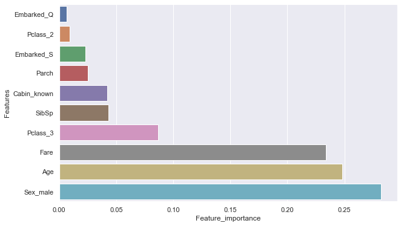

```python
plt.figure(figsize=(10,6))
sns.barplot(y='Features', x='Feature_importance', data=FIM)
```

From the feature importance plot, it seems that gender, fare and age where the top 3 important factors predicting the survivorship of the passenger.

### Question 2: Kaggle csv submission

```python
RF_classifier_optimized = RandomForestClassifier(n_estimators=100,criterion='entropy', max_depth=10, max_features=10, random_state=500)
RF_classifier_optimized.fit(X_train, y_train)
y_hat_optimal = RF_classifier_optimized.predict(X_test)
```

```python
predictions = pd.DataFrame(y_hat_optimal, columns=["Survived"])
predictions.head()
```

|  | Survived |
| --- | --- |
| 0 | 0 |
| 1 | 0 |
| 2 | 0 |
| 3 | 0 |
| 4 | 1 |

```python
Kaggle_submission= pd.concat([df_test['PassengerId'],predictions], axis=1)
```

```python
Kaggle_submission.head()
```

|  | PassengerId | Survived |
| --- | --- | --- |
| 0 | 892 | 0 |
| 1 | 893 | 0 |
| 2 | 894 | 0 |
| 3 | 895 | 0 |
| 4 | 896 | 1 |

```python
Kaggle_submission.to_csv("Titanic_RF.csv", index=False)
```

### My score in Kaggle competition:

- Logistic regression: Score 0.77033 , rank 10,410
- KNN Classification : Score 0.77511 , rank 9,767
- SVM Classification: Score **0.78947** , rank **3,463**
- RF Classification: Score 0.76555, rank: latest one is 3,222.

So far, the SVM with C=100 and gamma=0.01 is the best model!!